# Creating Cohorts of Songs.

```python
df.columns
```

```
Index(['satisfaction_level', 'last_evaluation', 'number_project',
       'average_montly_hours', 'time_spend_company', 'Work_accident', 'left',
       'promotion_last_5years', 'sales', 'salary'],
      dtype='object')
```

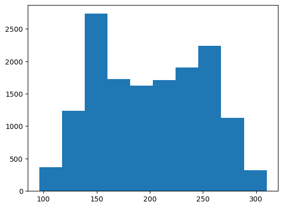

```python
plt.hist(df["average_montly_hours"])
```

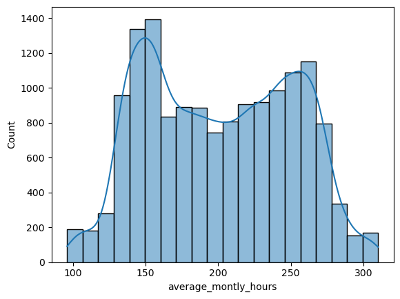

```python
sns.histplot(data = df,x="average_montly_hours", kde = True,bins=20)
```

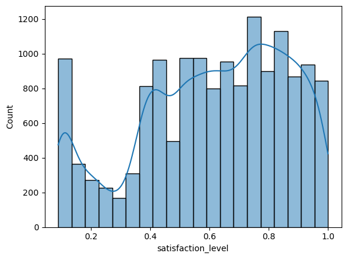

```python
sns.histplot(data = df,x="satisfaction_level", kde = True,bins=20)
```

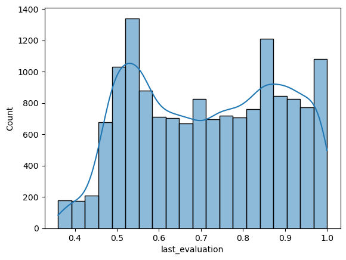

```python
sns.histplot(data = df,x="last_evaluation", kde = True,bins=20)
```

[output not shown]

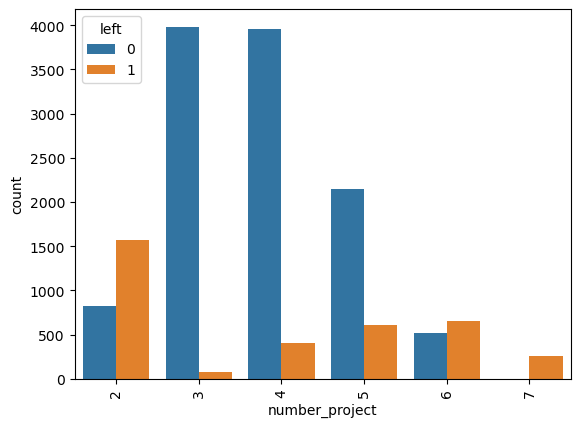

```python
sns.countplot(x="number_project",hue="left",data=df)
plt.xticks(rotation=90)
```

```python
dfclus = df[["satisfaction_level","last_evaluation","left"]]
```

```python
dfclus
```

|  | satisfaction_level | last_evaluation | left |
| --- | --- | --- | --- |
| 0 | 0.38 | 0.53 | 1 |
| 1 | 0.80 | 0.86 | 1 |
| 2 | 0.11 | 0.88 | 1 |
| 3 | 0.72 | 0.87 | 1 |
| 4 | 0.37 | 0.52 | 1 |
| ... | ... | ... | ... |
| 14994 | 0.40 | 0.57 | 1 |
| 14995 | 0.37 | 0.48 | 1 |
| 14996 | 0.37 | 0.53 | 1 |
| 14997 | 0.11 | 0.96 | 1 |
| 14998 | 0.37 | 0.52 | 1 |

14999 rows × 3 columns

```python
from sklearn.cluster import KMeans
```

```python
km=dfclus.iloc[:,:].values
kmeans = KMeans(n_clusters=3, random_state=0)
label = kmeans.fit_predict(dfclus)
labelarr = kmeans.fit_predict(km)
```

```python
label
```

```
array([1, 1, 1, ..., 1, 1, 1])
```

```python
dfclus[label==0].describe()
```

|  | satisfaction_level | last_evaluation | left |
| --- | --- | --- | --- |
| count | 6720.000000 | 6720.000000 | 6720.0 |
| mean | 0.813112 | 0.739728 | 0.0 |
| std | 0.108167 | 0.154900 | 0.0 |
| min | 0.590000 | 0.360000 | 0.0 |
| 25% | 0.720000 | 0.610000 | 0.0 |
| 50% | 0.810000 | 0.740000 | 0.0 |
| 75% | 0.910000 | 0.870000 | 0.0 |
| max | 1.000000 | 1.000000 | 0.0 |

```python
dfclus[label==1].describe()
```

|  | satisfaction_level | last_evaluation | left |
| --- | --- | --- | --- |
| count | 3571.000000 | 3571.000000 | 3571.0 |
| mean | 0.440098 | 0.718113 | 1.0 |
| std | 0.263933 | 0.197673 | 0.0 |
| min | 0.090000 | 0.450000 | 1.0 |
| 25% | 0.130000 | 0.520000 | 1.0 |
| 50% | 0.410000 | 0.790000 | 1.0 |
| 75% | 0.730000 | 0.900000 | 1.0 |
| max | 0.920000 | 1.000000 | 1.0 |

```python
dfclus[label==2].describe()
```

|  | satisfaction_level | last_evaluation | left |
| --- | --- | --- | --- |
| count | 4708.000000 | 4708.000000 | 4708.0 |
| mean | 0.457984 | 0.680854 | 0.0 |
| std | 0.153456 | 0.165609 | 0.0 |
| min | 0.120000 | 0.360000 | 0.0 |
| 25% | 0.350000 | 0.550000 | 0.0 |
| 50% | 0.510000 | 0.670000 | 0.0 |
| 75% | 0.570000 | 0.810000 | 0.0 |
| max | 0.690000 | 1.000000 | 0.0 |

```python
km[label==0,1]
```

```
array([0.67, 0.82, 0.91, ..., 0.55, 0.95, 0.54])
```

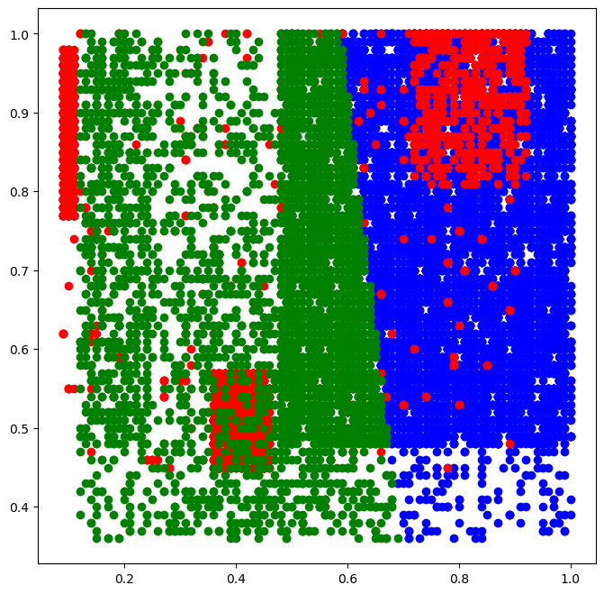

```python
plt.figure(figsize=(8,8))
plt.scatter(km[label==0,0],km[label==0,1],color="blue")
plt.scatter(km[label==1,0],km[label==1,1],color="red")
plt.scatter(km[label==2,0],km[label==2,1],color="green")
```

The Blue cluster denotes people with best satisfaction levels and scored high in the last evaluation.

The Red cluster denotes people with medium satisfaction levels and scored average to high in the last evaluation

```python
df.info()
```

```
<class 'pandas.core.frame.DataFrame'>
RangeIndex: 14999 entries, 0 to 14998
Data columns (total 10 columns):
 #   Column                 Non-Null Count  Dtype
---  ------                 --------------  -----
 0   satisfaction_level     14999 non-null  float64
 1   last_evaluation        14999 non-null  float64
 2   number_project         14999 non-null  int64
 3   average_montly_hours   14999 non-null  int64
 4   time_spend_company     14999 non-null  int64
 5   Work_accident          14999 non-null  int64
 6   left                   14999 non-null  int64
 7   promotion_last_5years  14999 non-null  int64
 8   sales                  14999 non-null  object
 9   salary                 14999 non-null  object
dtypes: float64(2), int64(6), object(2)
memory usage: 1.1+ MB
```

```python
df_numerical=df.select_dtypes(include=['int64','float64'])
df_categorical=df.select_dtypes(include=['object'])
```

Converting the categorical data into numerical using one hot encoding

```python
#df = pd.get_dummies(data=df,columns=['sales','salary'])
df_converted = pd.get_dummies(data=df_categorical)
```

```python
df_converted.head()
```

|  | sales_IT | sales_RandD | sales_accounting | sales_hr | sales_management | sales_marketing | sales_product_mng | sales_sales | sales_support | sales_technical | salary_high | salary_low | salary_medium |
| --- | --- | --- | --- | --- | --- | --- | --- | --- | --- | --- | --- | --- | --- |
| 0 | 0 | 0 | 0 | 0 | 0 | 0 | 0 | 1 | 0 | 0 | 0 | 1 | 0 |
| 1 | 0 | 0 | 0 | 0 | 0 | 0 | 0 | 1 | 0 | 0 | 0 | 0 | 1 |
| 2 | 0 | 0 | 0 | 0 | 0 | 0 | 0 | 1 | 0 | 0 | 0 | 0 | 1 |
| 3 | 0 | 0 | 0 | 0 | 0 | 0 | 0 | 1 | 0 | 0 | 0 | 1 | 0 |
| 4 | 0 | 0 | 0 | 0 | 0 | 0 | 0 | 1 | 0 | 0 | 0 | 1 | 0 |

```python
dfn = pd.concat([df_numerical, df_converted], axis=1, join="inner")
```

```python
dfn.shape
```

```
(14999, 21)
```

```python
dfn.head()
```

|  | satisfaction_level | last_evaluation | number_project | average_montly_hours | time_spend_company | Work_accident | left | promotion_last_5years | sales_IT | sales_RandD | ... | sales_hr | sales_management | sales_marketing | sales_product_mng | sales_sales | sales_support | sales_technical | salary_high | salary_low | salary_medium |
| --- | --- | --- | --- | --- | --- | --- | --- | --- | --- | --- | --- | --- | --- | --- | --- | --- | --- | --- | --- | --- | --- |
| 0 | 0.38 | 0.53 | 2 | 157 | 3 | 0 | 1 | 0 | 0 | 0 | ... | 0 | 0 | 0 | 0 | 1 | 0 | 0 | 0 | 1 | 0 |
| 1 | 0.80 | 0.86 | 5 | 262 | 6 | 0 | 1 | 0 | 0 | 0 | ... | 0 | 0 | 0 | 0 | 1 | 0 | 0 | 0 | 0 | 1 |
| 2 | 0.11 | 0.88 | 7 | 272 | 4 | 0 | 1 | 0 | 0 | 0 | ... | 0 | 0 | 0 | 0 | 1 | 0 | 0 | 0 | 0 | 1 |
| 3 | 0.72 | 0.87 | 5 | 223 | 5 | 0 | 1 | 0 | 0 | 0 | ... | 0 | 0 | 0 | 0 | 1 | 0 | 0 | 0 | 1 | 0 |
| 4 | 0.37 | 0.52 | 2 | 159 | 3 | 0 | 1 | 0 | 0 | 0 | ... | 0 | 0 | 0 | 0 | 1 | 0 | 0 | 0 | 1 | 0 |

5 rows × 21 columns

Splitting the dataset into training and testing in the ratio of 80:20 with random state = 123.

```python
x =dfn.drop("left",axis=1)
y = dfn["left"]
```

```python
from sklearn.model_selection import train_test_split
xtrain,xtest,ytrain,ytest = train_test_split(x,y,test_size=0.2,random_state=123)
```

```python
xtrain.shape,ytrain.shape,xtest.shape,ytest.shape
```

```
((11999, 20), (11999,), (3000, 20), (3000,))
```

```python
ytrain.value_counts()
```

```
0    9137
1    2862
Name: left, dtype: int64
```

Data is highly imbalanced for the training dataset as the record of people who left is very low in comparision to the record of people who didn't leave.

Using SMOTE to handle the imbalance for the left category

```python
pip install imblearn
```

```python
from imblearn.over_sampling import SMOTE
```

```python
sm = SMOTE(random_state = 2)
xtrainres, ytrainres = sm.fit_resample(xtrain, ytrain)
```

```python
ytrainres.value_counts()
```

```
0    9137
1    9137
Name: left, dtype: int64
```

```python
from sklearn.model_selection import cross_val_score
from sklearn.linear_model import LogisticRegression
from sklearn.ensemble import RandomForestClassifier
from sklearn.metrics import roc_auc_score
import sklearn.metrics as metrics
```

```python
logreg = LogisticRegression(solver='lbfgs', max_iter=10000)
```

```python
print(cross_val_score(logreg, xtrainres, ytrainres, cv=5).mean())
```

```
0.8060648263582364
```

```python
logreg.fit(xtrainres,ytrainres)
ypred = logreg.predict(xtest)
```

```python
from sklearn.metrics import classification_report
```

Logistic regression report

```python
metrics.confusion_matrix(ytest,ypred)
```

```
array([[1829,  462],
       [ 229,  480]], dtype=int64)
```

```python
print(classification_report(ytest,ypred))
```

```
              precision    recall  f1-score   support

           0       0.89      0.80      0.84      2291
           1       0.51      0.68      0.58       709

    accuracy                           0.77      3000
   macro avg       0.70      0.74      0.71      3000
weighted avg       0.80      0.77      0.78      3000
```

```python
roc_auc_score(ytest,ypred)
```

```
0.7376756043609659
```

```
[0.         0.20165866 1.        ]
[0.         0.67700987 1.        ]
[2 1 0]
0.7376756043609659
```

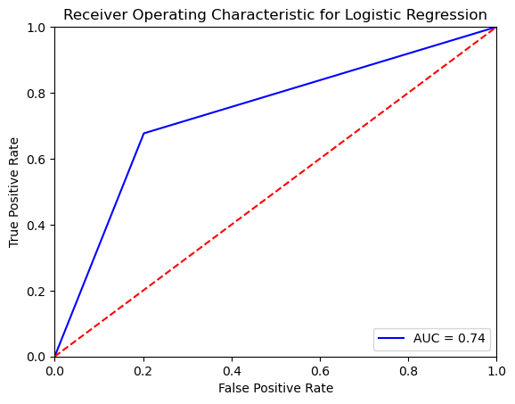

```python
fpr, tpr, threshold = metrics.roc_curve(ytest, ypred)
print(fpr)
print(tpr)
print(threshold)
roc_auc = metrics.auc(fpr, tpr)
print(roc_auc)

# method I: plt
plt.title('Receiver Operating Characteristic for Logistic Regression')
plt.plot(fpr, tpr, 'b', label = 'AUC = %0.2f' % roc_auc)
plt.legend(loc = 'lower right')
plt.plot([0, 1], [0, 1],'r--')
plt.xlim([0, 1])
plt.ylim([0, 1])
plt.ylabel('True Positive Rate')
plt.xlabel('False Positive Rate')
plt.show()
```

Random Forest Classifier

```python
randm=RandomForestClassifier(max_depth=5)
```

```python
print(cross_val_score(randm, xtrainres, ytrainres, cv=5).mean())
```

```
0.9491627263041009
```

```python
randm.fit(xtrainres,ytrainres)
ypred1=randm.predict(xtest)
```

Random Forest Classification report

```python
metrics.confusion_matrix(ytest,ypred1)
```

```
array([[2226,   65],
       [  57,  652]], dtype=int64)
```

```python
print(classification_report(ytest,ypred1))
```

```
              precision    recall  f1-score   support

           0       0.98      0.97      0.97      2291
           1       0.91      0.92      0.91       709

    accuracy                           0.96      3000
   macro avg       0.94      0.95      0.94      3000
weighted avg       0.96      0.96      0.96      3000
```

```python
roc_auc_score(ytest,ypred1)
```

```
0.9456165937848415
```

```
[0.         0.02837189 1.        ]
[0.         0.91960508 1.        ]
[2 1 0]
0.9456165937848415
```

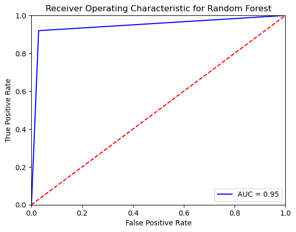

```python
fpr, tpr, threshold = metrics.roc_curve(ytest, ypred1)
print(fpr)
print(tpr)
print(threshold)
roc_auc = metrics.auc(fpr, tpr)
print(roc_auc)

# method I: plt
plt.title('Receiver Operating Characteristic for Random Forest')
plt.plot(fpr, tpr, 'b', label = 'AUC = %0.2f' % roc_auc)
plt.legend(loc = 'lower right')
plt.plot([0, 1], [0, 1],'r--')
plt.xlim([0, 1])
plt.ylim([0, 1])
plt.ylabel('True Positive Rate')
plt.xlabel('False Positive Rate')
plt.show()
```

Gradient Boosting Classifier

```python
from sklearn.ensemble import GradientBoostingClassifier
```

```python
gb = GradientBoostingClassifier(n_estimators=100, learning_rate=1.0,max_depth=1, random_state=0)
```

```python
print(cross_val_score(gb, xtrainres, ytrainres, cv=5).mean())
```

```
0.9472476764028253
```

```python
gb.fit(xtrainres,ytrainres)
```

```
GradientBoostingClassifier(learning_rate=1.0, max_depth=1, random_state=0)
```

```python
ypred2 = gb.predict(xtest)
```

Gradient boosting Classification Report

```python
metrics.confusion_matrix(ytest,ypred2)
```

```
array([[2172,  119],
       [  46,  663]], dtype=int64)
```

```python
print(classification_report(ytest,ypred2))
```

```
              precision    recall  f1-score   support

           0       0.98      0.95      0.96      2291
           1       0.85      0.94      0.89       709

    accuracy                           0.94      3000
   macro avg       0.91      0.94      0.93      3000
weighted avg       0.95      0.94      0.95      3000
```

```python
roc_auc_score(ytest,ypred2)
```

```
0.9415887519631305
```

```
[0.         0.05194238 1.        ]
[0.         0.93511989 1.        ]
[2 1 0]
0.9415887519631305
```

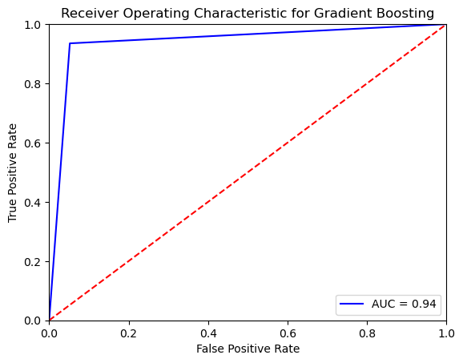

```python
fpr, tpr, threshold = metrics.roc_curve(ytest, ypred2)
print(fpr)
print(tpr)
print(threshold)
roc_auc = metrics.auc(fpr, tpr)
print(roc_auc)

# method I: plt
plt.title('Receiver Operating Characteristic for Gradient Boosting')
plt.plot(fpr, tpr, 'b', label = 'AUC = %0.2f' % roc_auc)
plt.legend(loc = 'lower right')
plt.plot([0, 1], [0, 1],'r--')
plt.xlim([0, 1])
plt.ylim([0, 1])
plt.ylabel('True Positive Rate')
plt.xlabel('False Positive Rate')
plt.show()
```

Based on the confusion matrix, the false negatives should be low because if an employee who might leave the organisation is misclassified as someone who won't leave then proper strategies to retain that person will not be implemented on him or her. Hence Recall is better metric to be used

```python
col = xtrainres.columns
```

```python
col
```

```
Index(['satisfaction_level', 'last_evaluation', 'number_project',
       'average_montly_hours', 'time_spend_company', 'Work_accident',
       'promotion_last_5years', 'sales_IT', 'sales_RandD', 'sales_accounting',
       'sales_hr', 'sales_management', 'sales_marketing', 'sales_product_mng',
       'sales_sales', 'sales_support', 'sales_technical', 'salary_high',
       'salary_low', 'salary_medium'],
      dtype='object')
```

Since Random Forest shows the highest accuracy with good f1 score, we will conclude that to be our best performing model.

```python
feature_labels = np.array(col)
```

```python
importance = randm.feature_importances_
feature_indexes_by_importance = importance.argsort()
for index in feature_indexes_by_importance:
    print('{}-{:.2f}%'.format(feature_labels[index], (importance[index] *100.0)))
```

```
sales_accounting-0.01%
sales_marketing-0.02%
sales_hr-0.02%
sales_support-0.03%
sales_technical-0.05%
sales_IT-0.05%
sales_product_mng-0.06%
sales_sales-0.06%
promotion_last_5years-0.09%
sales_RandD-0.18%
sales_management-0.26%
salary_medium-0.33%
salary_low-0.60%
salary_high-2.00%
Work_accident-3.41%
last_evaluation-10.21%
average_montly_hours-11.27%
number_project-19.59%
time_spend_company-22.44%
satisfaction_level-29.32%
```

The above lists the factors that influences the turnover in the ascending order. It can be identified that the employee turnover is highly influenced by the employee's satisfaction level in the organisation. Improvement of work culture within the organiation can be a good way to prevent the employees from leaving the organisation.

```python
predict_probability = randm.predict_proba(xtest)
```

```python
predict_probability[:,1]
```

```
array([0.05900977, 0.0987141 , 0.10328423, ..., 0.68288382, 0.07704356,
       0.13726451])
```

```python
zone=[]
prob=[]

for i in predict_probability[:,1]:
  prob.append(i)
  if (i<=0.2):
    zone.append("Safe Zone")
  elif (i>0.2 and i<=0.6):
    zone.append("Low Risk Zone")
  elif (i>0.6 and i<=0.9):
    zone.append("Medium Risk Zone ")
  else:
    zone.append("High Risk Zone ")
```

```python
categories = ["Safe Zone","Low Risk Zone","Medium Risk Zone ","High Risk Zone "]
color = ["Green","Yellow","Orange","Red"]
```

```python
colordict = dict(zip(categories, color))
```

```python
clr = pd.DataFrame({"zone":zone,"probability":prob})
```

```python
clr["zone"].unique()
```

```
array(['Safe Zone', 'High Risk Zone ', 'Medium Risk Zone ',
       'Low Risk Zone'], dtype=object)
```

```python
clr["Color"] = clr["zone"].apply(lambda x: colordict[x])
```

```python
clr.head(10)
```

|  | zone | probability | Color |
| --- | --- | --- | --- |
| 0 | Safe Zone | 0.059010 | Green |
| 1 | Safe Zone | 0.098714 | Green |
| 2 | Safe Zone | 0.103284 | Green |
| 3 | Safe Zone | 0.087709 | Green |
| 4 | Safe Zone | 0.105928 | Green |
| 5 | Safe Zone | 0.085072 | Green |
| 6 | High Risk Zone | 0.937462 | Red |
| 7 | Medium Risk Zone | 0.719362 | Orange |
| 8 | Safe Zone | 0.144547 | Green |
| 9 | Safe Zone | 0.081007 | Green |

```python
color= clr["Color"].tolist()
```

```python
c = ["Green","Red","Orange","Yellow"]
```

[output not shown]

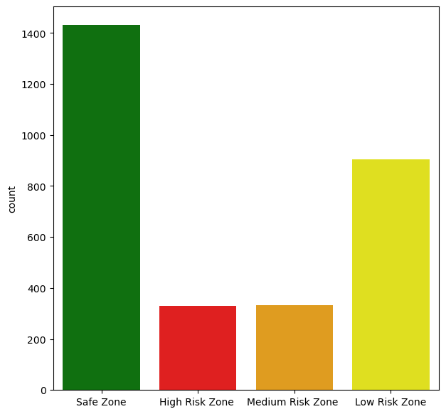

```python
plt.figure(figsize=(7,7))
sns.countplot(zone,palette=c)
```

# ..............................................................................................ANANT KALEKAR